# Prak07-1119015-Valentinus

```python
from scipy.stats import norm
import numpy as np
import matplotlib.pyplot as plt
```

```python
lessthan2=norm.cdf(x=2, loc=3, scale=2)
```

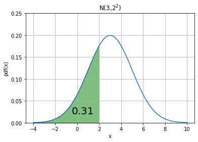

```python
fig, ax = plt.subplots()
# for distribution curve
x= np.arange(-4,10,0.001)
ax.plot(x, norm.pdf(x,loc=3,scale=2))
ax.set_title("N(3,$2^2$)")
ax.set_xlabel('x')
ax.set_ylabel('pdf(x)')
ax.grid(True)

# for fill_between
px=np.arange(-4,2,0.01)
ax.set_ylim(0,0.25)
ax.fill_between(px,norm.pdf(px,loc=3,scale=2),alpha=0.5, color='g')

# fortext
ax.text(-0.5,0.02,round(lessthan2,2), fontsize=20)
plt.show()
```

#### Dari visualisasi diatas dapat kita lihat bahwa distribusinya normal. Selain itu dapat dilihat dari bagian yang diwarnai hijau bahwa peluang nilai x kurang dari atau sama dengan 2 yaitu sebesar 0.31.

```python
norm(1, 2).cdf(2) - norm(1,2).cdf(0.5)
```

```
0.2901687869569368
```

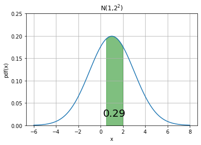

```python
fig, ax = plt.subplots()

# for distribution curve
x= np.arange(-6,8,0.001)
ax.plot(x, norm.pdf(x,loc=1,scale=2))
ax.set_title("N(1,$2^2$)")
ax.set_xlabel('x')
ax.set_ylabel('pdf(x)')
ax.grid(True)

px=np.arange(0.5,2,0.01)
ax.set_ylim(0,0.25)
ax.fill_between(px,norm.pdf(px,loc=1,scale=2),alpha=0.5, color='g')

pro=norm(1, 2).cdf(2) - norm(1,2).cdf(0.5)
ax.text(0.2,0.02,round(pro,2), fontsize=20)
plt.show()
```

```python
gr4sf=norm.sf(x=4, loc=3, scale=2)
gr4sf
```

```
0.3085375387259869
```

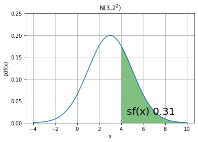

```python
fig, ax = plt.subplots()
x= np.arange(-4,10,0.001)
ax.plot(x, norm.pdf(x,loc=3,scale=2))
ax.set_title("N(3,$2^2$)")
ax.set_xlabel('x')
ax.set_ylabel('pdf(x)')
ax.grid(True)

px=np.arange(4,10,0.01)
ax.set_ylim(0,0.25)
ax.fill_between(px,norm.pdf(px,loc=3,scale=2),alpha=0.5, color='g')
ax.text(4.5,0.02,"sf(x) %.2f" %(gr4sf), fontsize=20)
plt.show()
```

#### Dengan menggunakan mean = 3 dan standard deviation =2. maka akan gunakan nilai P(x>4), dimana x adalah > 4 dan nilai akhir 0.31.

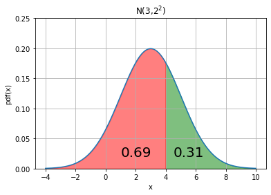

```python
gr4=norm.cdf(x=4, loc=3, scale=2)
gr14=1-gr4

fig, ax = plt.subplots()
x= np.arange(-4,10,0.001)
ax.plot(x, norm.pdf(x,loc=3,scale=2))
ax.set_title("N(3,$2^2$)")
ax.set_xlabel('x')
ax.set_ylabel('pdf(x)')
ax.grid(True)

px=np.arange(4,10,0.01)
ax.set_ylim(0,0.25)
ax.fill_between(px,norm.pdf(px,loc=3,scale=2),alpha=0.5, color='g')
px1=np.arange(-4,4,0.01)
ax.fill_between(px1,norm.pdf(px1,loc=3,scale=2),alpha=0.5, color='r')
ax.text(4.5,0.02,round(gr14,2), fontsize=20)
ax.text(1,0.02,round(gr4,2), fontsize=20)
plt.show()
```

#### Dari grafik di atas membuktikan bahwa probabilitas dari distribusi normal dapat dicari. dan dari grafik tersebut juga di bawah 4 bernilai 0.69, sedangkan di atas 4 adalah 0.31 yang jika dijumlah menjadi total 1.

```python
norm.ppf(q=0.506, loc=1, scale=3)
```

```
1.045121010035907
```

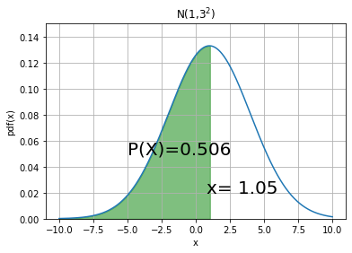

```python
fig, ax = plt.subplots()
x= np.arange(-10,10,0.001)
ax.plot(x, norm.pdf(x,loc=1,scale=3))
ax.set_title("N(1,$3^2$)")
ax.set_xlabel('x')
ax.set_ylabel('pdf(x)')
ax.grid(True)

xpoint=norm.ppf(q=0.506, loc=1, scale=3)
px=np.arange(-10,xpoint,0.01)
ax.set_ylim(0,0.15)
ax.fill_between(px,norm.pdf(px,loc=1,scale=3),alpha=0.5, color='g')

ax.text(.8,0.02,"x= %.2f" %xpoint, fontsize=20)
ax.text(-5,0.05,"P(X)=0.506", fontsize=20)
plt.show()
```

#### Dari grafik di atas , kemungkinan nilai x < 1.05 adalah 0.506 atau 50,6%.

```python
norm.isf(q=0.198, loc=1, scale=3)
```

```
3.5463600577479006
```

```python
norm.ppf(q=(1-0.198), loc=1, scale=3)
```

```
3.546360057747901
```

```python
a,b = norm.interval(alpha=0.95, loc=0, scale=1)
print(a,b)
```

```
-1.959963984540054 1.959963984540054
```

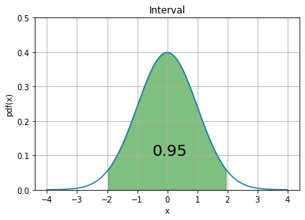

```python
fig, ax = plt.subplots()
x= np.arange(-4,4,0.001)
ax.plot(x, norm.pdf(x))
ax.set_title("Interval")
ax.set_xlabel('x')
ax.set_ylabel('pdf(x)')
ax.grid(True)

px=np.arange(a,b,0.01)
ax.set_ylim(0,0.5)
ax.fill_between(px,norm.pdf(px),alpha=0.5, color='g')

ax.text(-0.5,0.1,"0.95", fontsize=20)
plt.show()
```

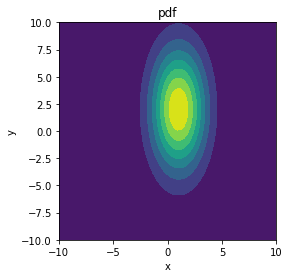

```python
from scipy.stats import multivariate_normal

x,y = np.meshgrid(np.linspace(-10,10,100),np.linspace(-10,10,100))
pos = np.dstack((x,y))
mean = np.array([1, 2])
cov = np.array([[3,0],[0,15]])
rv = multivariate_normal(mean,cov)
z = rv.pdf(pos)

fig = plt.figure()
ax =fig.add_subplot(111,aspect='equal')
ax.contourf(x,y,z)
ax.set_xlim(-10,10)
ax.set_ylim(-10,10)
ax.set_xlabel('x')
ax.set_ylabel('y')
ax.set_title('pdf')
```

#### Dari gambar di atas , Menggambarkan kumpulan mean dan matriks kovarian. Menjadikannya sederhana, dengan menggunakan diagonal matriks.

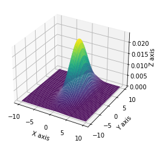

```python
import numpy as np
import matplotlib.pyplot as plt
from scipy.stats import multivariate_normal
from mpl_toolkits.mplot3d import Axes3D

# Create grid and multivariate normal
x = np.linspace(-10,10,500)
y = np.linspace(-10,10,500)
X, Y = np.meshgrid(x,y)
pos = np.empty(X.shape + (2,))
pos[:, :, 0] = X
pos[:, :, 1] = Y

# Createafrozen RV object
mean = np.array([1, 2])
cov = np.array([[3,0],[0,15]])
rv = multivariate_normal(mean,cov)

# Make a 3D plot
fig = plt.figure()
ax =fig.gca(projection='3d')
ax.plot_surface(X, Y, rv.pdf(pos),cmap='viridis',linewidth=0)
ax.set_xlabel('X axis')
ax.set_ylabel('Y axis')
ax.set_zlabel('Z axis')
plt.show()
```

```python
norm.cdf(1, loc=2, scale=3)
```

```
0.36944134018176367
```

```python
norm.ppf(q=norm.cdf(1, loc=2, scale=3))
```

```
-0.33333333333333326
```